# Protein Genes + Duplicated genes

**Libraries**

```r
library(rtracklayer)
library(GenomicFeatures)
library(txdbmaker)
library(Biostrings)
library(BSgenome)
library(BSgenomeForge)
library(dplyr)
library(GenomicRanges)
library(GenomeInfoDb)
library(Biostrings)
library(BSgenome)
library(ggplot2)
library(scales)
library(ggpointdensity)
```

**Loading data - Loading seqs + filtering**

```r
library(BSgenome.Dlaeve.NCBI.dlgm)
genome <- BSgenome.Dlaeve.NCBI.dlgm
```

```r
print(class(genome))
```

## [1] “BSgenome”

## attr(,“package”)

## [1] “BSgenome”

```r
length(genome)
```

## [1] 3497

```r
genome
```

## | BSgenome object

## | - organism: Deroceras laeve

## | - provider: NCBI

## | - genome: dl_gm

## | - 3497 sequence(s):

## | chr1 chr2 chr3 chr4

## | chr5 chr6 chr7 chr8

## | chr9 chr10 chr11 chr12

## | chr13 chr14 chr15 chr16

## | chr17 chr18 chr19 chr20

## | … … … …

## | HiC_scaffold_3481 HiC_scaffold_3482 HiC_scaffold_3483 HiC_scaffold_3484

## | HiC_scaffold_3485 HiC_scaffold_3486 HiC_scaffold_3487 HiC_scaffold_3488

## | HiC_scaffold_3489 HiC_scaffold_3490 HiC_scaffold_3491 HiC_scaffold_3492

## | HiC_scaffold_3493 HiC_scaffold_3494 HiC_scaffold_3495 HiC_scaffold_3496

## | HiC_scaffold_3497

## |

## | Tips: call ‘seqnames()’ on the object to get all the sequence names, call ‘seqinfo()’ to

## | get the full sequence info, use the ‘$’ or ‘[[’ operator to access a given sequence, see

## | ‘?BSgenome’ for more information.

```r
# names present in your BSgenome
nm  <- seqnames(genome)

# choose only proper chromosomes (e.g. chr1..chr31), ignore the HiC_scaffold zoo
keep <- intersect(paste0("chr", 1:31), nm)          # safe even if some are missing

# grab them quickly as a DNAStringSet (lightweight, fast)
genome_chr <- getSeq(genome, keep)

# sanity check
length(genome_chr); head(names(genome_chr))
```

## [1] 31## [1] “chr1” “chr2” “chr3” “chr4” “chr5” “chr6”

```r
transcriptome <- import("C:/Users/rafae/OneDrive/Desktop/Genomics/derLaeGenome_namesDlasi_v2.fasta.functional_note.pseudo_label.gff")
```

```r
transcriptome
```

## GRanges object with 1756563 ranges and 17 metadata columns:

## seqnames ranges strand | source type score

## |

## [1] HiC_scaffold_1005 6207-7268 - | EviAnn gene NA

## [2] HiC_scaffold_1005 6207-7268 - | EviAnn mRNA NA

## [3] HiC_scaffold_1005 6207-7268 - | EviAnn exon NA

## [4] HiC_scaffold_1005 6207-7268 - | EviAnn CDS NA

## [5] HiC_scaffold_1005 7529-9631 + | EviAnn gene NA

## … … … … . … … …

## [1756559] chr9 73153203-73153305 - | EviAnn CDS NA

## [1756560] chr9 73155022-73155165 - | EviAnn CDS NA

## [1756561] chr9 73157349-73157465 - | EviAnn CDS NA

## [1756562] chr9 73161856-73161986 - | EviAnn CDS NA

## [1756563] chr9 73179656-73179782 - | EviAnn CDS NA

## phase ID geneID gene_biotype

## [1] LOC_00034091 LOC_00034091 protein_coding

## [2] LOC_00034091-mRNA-1 LOC_00034091 protein_coding

## [3]

## [4] 0

## [5] LOC_00034092 LOC_00034092 protein_coding

## … … … … …

## [1756559] 0

## [1756560] 0

## [1756561] 0

… [43 líneas truncadas]

```r
table(transcriptome$gene_biotype)
```

## lncRNA processed_pseudogene protein_coding

## 1832 871 120268

```r
proteinGenes <- transcriptome[transcriptome$type == "gene" & transcriptome$gene_biotype == "protein_coding"]
length(proteinGenes)
```

## [1] 35105

```r
# keep only chromosomes present in genome_chr, drop scaffolds safely
proteinGenes <- keepSeqlevels(proteinGenes, seqlevels(genome_chr), pruning.mode = "coarse")

# now set seqinfo to match your chromosome-only genome
seqinfo(proteinGenes) <- seqinfo(genome_chr)
```

```r
geneinfo <- mcols(proteinGenes)[c("geneID","Note")]
geneinfo
```

## DataFrame with 23216 rows and 2 columns

## geneID Note

## 1 LOC_00005583 Similar to ems: Home..

## 2 LOC_00005584 Similar to Cyp20a1: ..

## 3 LOC_00005585 Similar to CNBD2: Cy..

## 4 LOC_00005586 function unknown

## 5 LOC_00005587 Similar to MTX1: Met..

## … … …

## 23212 LOC_00000986 Similar to P65-C: Sy..

## 23213 LOC_00000987 Similar to F52C9.6: ..

## 23214 LOC_00000988 function unknown

## 23215 LOC_00000990 Similar to QKI: KH d..

## 23216 LOC_00000989 function unknown

```r
proteinGenes <- trim(proteinGenes)
proteinGenes_seqs <- getSeq(genome_chr, proteinGenes)
```

*Body*

```r
length(proteinGenes_seqs)
```

## [1] 23216

```r
proteinGenes_seqs
```

## DNAStringSet object of length 23216:

## width seq

## [1] 69367 TGTCGAGCTGTGCTACCAAGTGGACCTGTCCGGGTC…GAAAAGTTTATTTTCTTTCAATAAAATGATTCCAT

## [2] 48705 AGACAAACTAGCCACGGCGATTGTTGTTGACATCTG…CGGTGTCATCTTTTCGTCTTCTGTATTCATTCGTC

## [3] 81790 TTTCTTTGGGCAACTCAAGTTTAGGCTGGGGCAACC…TATGATGATTAGGACTTGATGTATTAGCTCTAGAT

## [4] 414 ATGATTGGCGGGGCTGTGGTCAACGCCCTCGCGTTT…TGACGGGGTTTGTGGCTTATAAACTGGCTAAGTAA

## [5] 67391 ATGGCGAAAGACGGAATGAAATTGTCGGTCTGGAAA…CCAGTCTAACAAAAGACATGGAGATAGATAAATAA

## … … …

## [23212] 152630 ATAGACGATGTGGTATCTAGCAATATTTTCTCAAGC…AGGTACTACACCACAAGACAGTGGCCCAGTAGTGT

## [23213] 834 ATGAATAAAATAACCACAATGGCATACCAAGACCCG…TCACGACACTCGAAAGGGTACAAGTGAAAAGATAA

## [23214] 2404 GATGCATTGTACGAGCTTCTATTCATGGTTCCAAGA…TTTTTTGCTTTCGTTTTATTGGCTTGCCAAGTCAG

## [23215] 44493 GTCGGGTCTACCCAGTCTTAAGACGTCGGGTCTACC…TTGTAACAGACTTGTGGTGTTTGTCACAGACTTGT

## [23216] 360 ATGAGATGTGCATTAACACAGCCACATAGGAAGCCA…CAGCTTTATCTACATTAGCTGCCAGTATTTTGTAG

**Counting**

```r
letterFrequency_all <- letterFrequency(proteinGenes_seqs, c("A", "T", "C", "G")) %>% as.data.frame %>% tibble()
letterFrequency_all
```

| A | T | C | G |
| --- | --- | --- | --- |
| 14742 | 22102 | 19764 | 12759 |
| 9352 | 16650 | 14615 | 8088 |
| 19448 | 19919 | 26771 | 15652 |
| 102 | 91 | 97 | 124 |
| 13363 | 18267 | 11276 | 24485 |
| 3564 | 3163 | 2499 | 2764 |
| 1509 | 1466 | 1249 | 1286 |
| 27058 | 21349 | 22574 | 23778 |
| 7195 | 10316 | 9677 | 7243 |
| 8506 | 10684 | 7719 | 7513 |

[output cut: 9990 more lines]

```r
C_all <- letterFrequency_all[3]
G_all <- letterFrequency_all[4]
Width_all <- width(proteinGenes_seqs)
CG_all <- dinucleotideFrequency(proteinGenes_seqs)[,"CG"]
```

```r
OE_all = (CG_all*Width_all)/(C_all*G_all)
colnames(OE_all) <- c("OEindex")
OE_all
```

| OEindex |
| --- |
| 0.61975869 |
| 0.30119722 |
| 0.54966543 |
| 1.06701031 |
| 0.05784890 |
| 0.21871846 |
| 0.49741193 |
| 0.11333698 |
| 0.24070576 |
| 0.40896006 |

[output cut: 9990 more lines]

```r
cgContent_all = (C_all+G_all)/Width_all
colnames(cgContent_all) <- c("CGpercentage")
cgContent_all
```

| CGpercentage |
| --- |
| 0.4688541 |
| 0.4661328 |
| 0.5186820 |
| 0.5338164 |
| 0.5306495 |
| 0.4389491 |
| 0.4600726 |
| 0.4891567 |
| 0.4914176 |
| 0.4425077 |

[output cut: 9990 more lines]

```r
df <- cbind(OE_all,cgContent_all)
df
```

| OEindex | CGpercentage |
| --- | --- |
| 0.61975869 | 0.4688541 |
| 0.30119722 | 0.4661328 |
| 0.54966543 | 0.5186820 |
| 1.06701031 | 0.5338164 |
| 0.05784890 | 0.5306495 |
| 0.21871846 | 0.4389491 |
| 0.49741193 | 0.4600726 |
| 0.11333698 | 0.4891567 |
| 0.24070576 | 0.4914176 |
| 0.40896006 | 0.4425077 |

[output cut: 9990 more lines]

**Graphs**

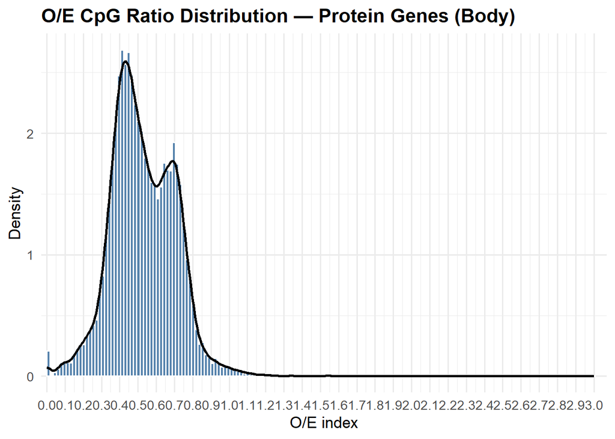

```r
x <- OE_all$OEindex
x <- x[is.finite(x)]
bw <- 2 * IQR(x) / length(x)^(1/3)
if (!is.finite(bw) || bw <= 0) bw <- diff(range(x)) / 80
xmin <- floor(min(x) * 10) / 10
xmax <- ceiling(max(x) * 10) / 10

ggplot(OE_all, aes(x = OEindex)) +
  geom_histogram(aes(y = after_stat(density)),
                 binwidth = bw, boundary = 0, closed = "left",
                 fill = "#4C7BA8", color = "white", alpha = 0.95) +
  geom_density(linewidth = 0.9, color = "black", alpha = 0.6) +
  scale_x_continuous(
    breaks = seq(xmin, xmax, by = 0.1),
    minor_breaks = seq(xmin, xmax, by = 0.05),
    labels = number_format(accuracy = 0.1),
    expand = expansion(mult = c(0.01, 0.02))
  ) +
  labs(
    title = "O/E CpG Ratio Distribution — Protein Genes (Body)",
    x = "O/E index",
    y = "Density"
  ) +
  theme_minimal(base_size = 13) +
  theme(
    panel.grid.minor = element_line(),
    plot.title = element_text(face = "bold")
  )
```

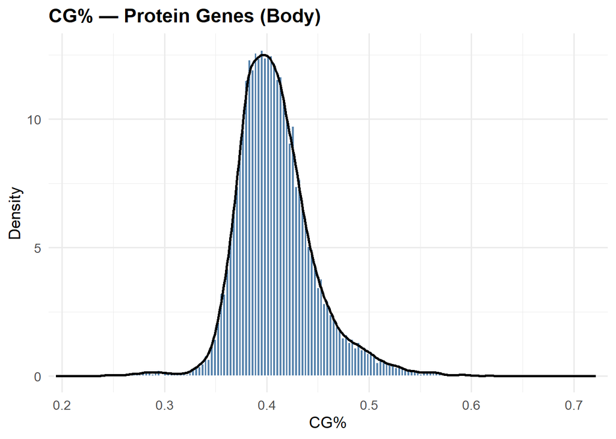

```r
x <- cgContent_all$CGpercentage
x <- x[is.finite(x)]
bw <- 2 * IQR(x) / length(x)^(1/3)
if (!is.finite(bw) || bw <= 0) bw <- diff(range(x)) / 80
xmin <- floor(min(x) * 10) / 10
xmax <- ceiling(max(x) * 10) / 10

ggplot(cgContent_all, aes(x = CGpercentage)) +
  geom_histogram(aes(y = after_stat(density)),
                 binwidth = bw, boundary = 0, closed = "left",
                 fill = "#4C7BA8", color = "white", alpha = 0.95) +
  geom_density(linewidth = 0.9, color = "black", alpha = 0.6) +
  scale_x_continuous(
    breaks = seq(xmin, xmax, by = 0.1),
    minor_breaks = seq(xmin, xmax, by = 0.05),
    labels = number_format(accuracy = 0.1),
    expand = expansion(mult = c(0.01, 0.02))
  ) +
  labs(
    title = "CG% — Protein Genes (Body)",
    x = "CG%",
    y = "Density"
  ) +
  theme_minimal(base_size = 13) +
  theme(
    panel.grid.minor = element_line(),
    plot.title = element_text(face = "bold")
  )
```

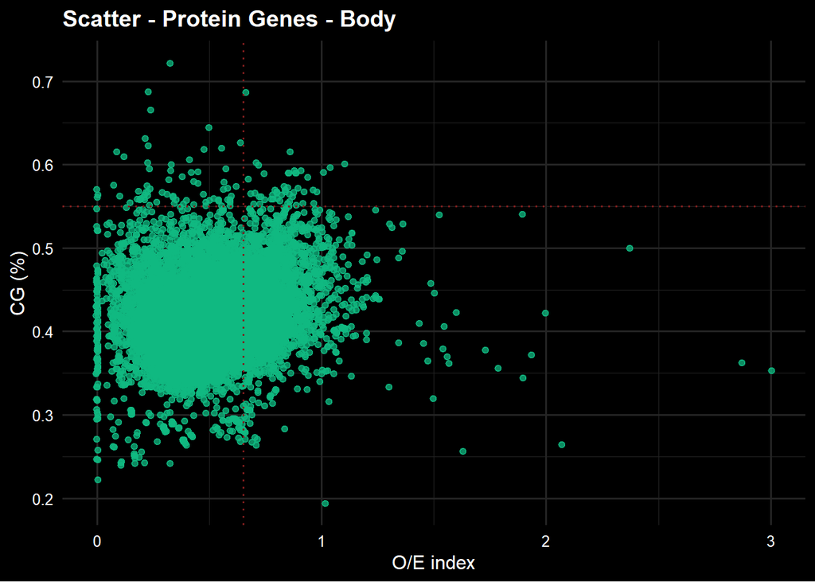

```r
plot_nice_dark <- function(d, x="OEindex", y="CGpercentage",
                           xthr=.65, ythr=.55, title="Scatter - Protein Genes - Body",
                           point_col="#10b981", thr_col="#7f1d1d"){   # green, violet
  dd <- data.frame(x=as.numeric(d[[x]]), y=as.numeric(d[[y]]))
  dd <- dd[is.finite(dd$x) & is.finite(dd$y), ]
  ggplot(dd, aes(x, y)) +
    geom_point(color=point_col, alpha=.75, size=1.6,
               position=position_jitter(width=.004, height=0)) +
    geom_vline(xintercept=xthr, color=thr_col, linewidth=.6, linetype="dotted") +
    geom_hline(yintercept=ythr, color=thr_col, linewidth=.6, linetype="dotted") +
    labs(title=title, x="O/E index", y="CG (%)") +
    theme_minimal(base_size=12) +
    theme(
      plot.background  = element_rect(fill="black", color=NA),
      panel.background = element_rect(fill="black", color=NA),
      panel.grid       = element_line(color="#242424"),
      axis.text        = element_text(color="white"),
      axis.title       = element_text(color="white"),
      plot.title       = element_text(color="white", face="bold")
    )
}

# use:
plot_nice_dark(df)
```

**PCA**

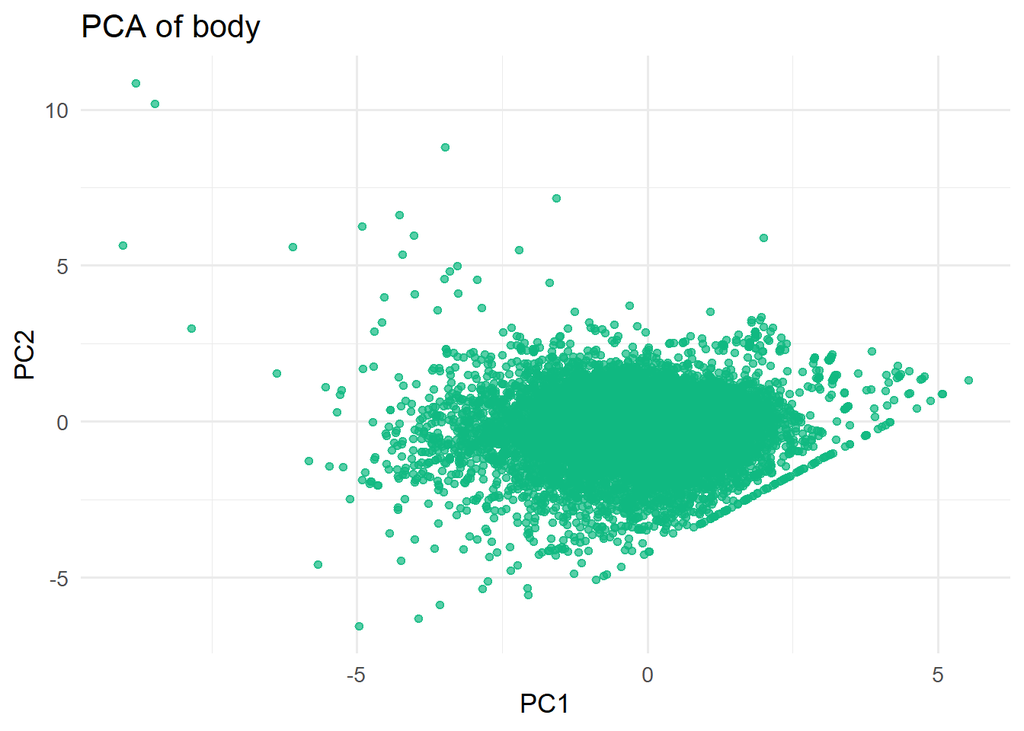

```r
# 1) Clean: keep numeric cols, drop NA/Inf rows, drop zero-variance cols
X <- df[, sapply(df, is.numeric), drop = FALSE]
X <- X[Reduce(`&`, lapply(X, is.finite)), , drop = FALSE]
X <- X[, sapply(X, function(z) sd(z) > 0), drop = FALSE]

# 2) PCA
pca <- prcomp(X, center = TRUE, scale. = TRUE)
pc  <- as.data.frame(pca$x[, 1:2, drop = FALSE])

ggplot(pc, aes(PC1, PC2)) +
  geom_point(alpha = .7, size = 1.6, color = "#10b981") +
  theme_minimal(base_size = 13) +
  labs(title = "PCA of body", x = "PC1", y = "PC2")
```

```r
summary(pca)
```

## Importance of components:

## PC1 PC2

## Standard deviation 1.1184 0.8656

## Proportion of Variance 0.6254 0.3746

## Cumulative Proportion 0.6254 1.0000

```r
cor(df$OEindex, df$CGpercentage)
```

## [1] NA

**K-Means**

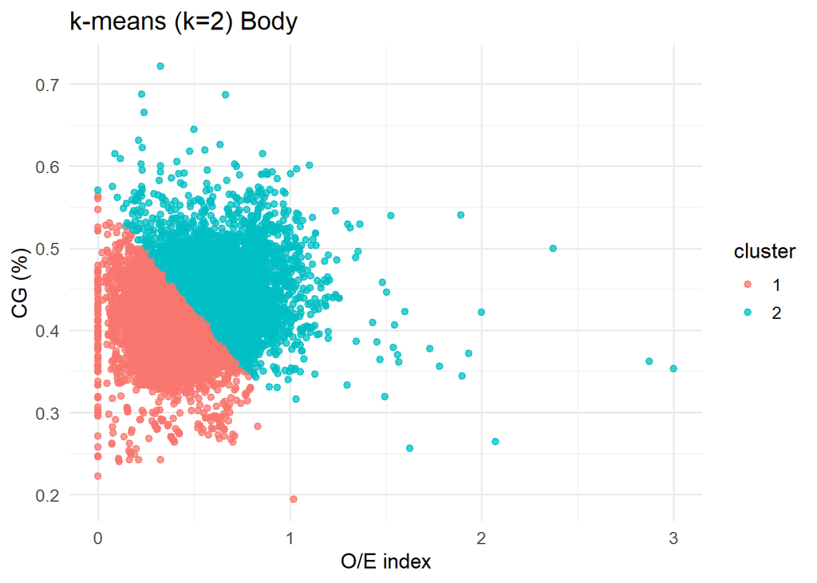

```r
# clean once; keep the mask so we can put labels back correctly
X <- df[, c("OEindex","CGpercentage")]
m <- is.finite(X$OEindex) & is.finite(X$CGpercentage)
Xc <- scale(X[m, , drop=FALSE])

set.seed(42)
k  <- 2
km <- kmeans(Xc, centers=k, nstart=50)

df$cluster <- NA_integer_
df$cluster[m] <- km$cluster
df$cluster <- factor(df$cluster)

ggplot(df[!is.na(df$cluster),], aes(OEindex, CGpercentage, color=cluster)) +
  geom_point(alpha=.75, size=1.7) +
  theme_minimal(base_size=13) +
  labs(title=sprintf("k-means (k=%d) Body", k),
       x="O/E index", y="CG (%)")
```

```r
names(geneinfo)
```

## [1] “geneID” “Note”

```r
names(df)
```

## [1] “OEindex” “CGpercentage” “cluster”

```r
df_genes <- data.frame(
  geneID = geneinfo$geneID,
  Note = S4Vectors::unstrsplit(geneinfo$Note, sep = "; "),
  df
)

df_genes
```

| geneID | Note | OEindex | CGpercentage | cluster |
| --- | --- | --- | --- | --- |
| LOC_00005583 | Similar to ems: Homeotic protein empty spiracles (Drosophila melanogaster) | 0.61975869 | 0.4688541 | 2 |
| LOC_00005584 | Similar to Cyp20a1: Cytochrome P450 20A1 (Mus musculus) | 0.30119722 | 0.4661328 | 1 |
| LOC_00005585 | Similar to CNBD2: Cyclic nucleotide-binding domain-containing protein 2 (Homo sapiens) | 0.54966543 | 0.5186820 | 2 |
| LOC_00005586 | function unknown | 1.06701031 | 0.5338164 | 2 |
| LOC_00005587 | Similar to MTX1: Metaxin-1 (Sus scrofa) | 0.05784890 | 0.5306495 | 1 |
| LOC_00005588 | Similar to NEIL1: Endonuclease 8-like 1 (Homo sapiens) | 0.21871846 | 0.4389491 | 1 |
| LOC_00005589 | function unknown | 0.49741193 | 0.4600726 | 2 |
| LOC_00005590 | Similar to DNTT: DNA nucleotidylexotransferase (Ambystoma mexicanum) | 0.11333698 | 0.4891567 | 1 |
| LOC_00005591 | Similar to DDX56: Probable ATP-dependent RNA helicase DDX56 (Homo sapiens) | 0.24070576 | 0.4914176 | 1 |
| LOC_00005592 | Similar to Haspin: Serine/threonine-protein kinase haspin (Mus musculus) | 0.40896006 | 0.4425077 | 1 |

[output cut: 9990 more lines]

**Repeated genes

```r
library(dplyr)
library(stringr)

mode1 <- function(x) names(sort(table(x), TRUE))[1]

prep <- df_genes %>%
  mutate(
    prefix   = str_match(Note, "(?i)\\bsimilar\\s*to\\s*([^:]+):")[,2],   # name before colon
    gene_key = ifelse(
      !is.na(prefix),
      prefix |> str_to_lower() |> str_replace_all("[^a-z0-9]", ""),      # DNMT1, dnmt1, Dnmt1 -> dnmt1
      paste0("raw:", str_squish(str_to_lower(Note)))                     # keep exact note as its own group
    )
  )

# 1) master table; gene is the full note (mode), includes "function unknown"
df1 <- prep %>%
  group_by(gene_key) %>%
  summarise(
    gene      = mode1(Note),                       # full "Similar to ... : ..." OR "function unknown"
    n         = n(),
    locs      = paste(geneID, collapse = "; "),
    notes_all = paste(unique(Note), collapse = " | "),
    .groups   = "drop"
  ) %>%
  arrange(desc(n), gene)

df1
```

| gene_key | gene | n | locs | notes_all |
| --- | --- | --- | --- | --- |
| raw:function unknown | function unknown | 7319 | LOC_00005586; LOC_00005589; LOC_00005595; LOC_00005596; LOC_00005598; LOC_00005607; LOC_00005611; LOC_00005614; LOC_00005615; LOC_00005617; LOC_00005618; LOC_00005620; LOC_00005621; LOC_00005622; LOC_… | function unknown |
| rtase | Similar to RTase: Probable RNA-directed DNA polymerase from transposon BS (Drosophila melanogaster) | 61 | LOC_00006681; LOC_00016937; LOC_00016944; LOC_00017398; LOC_00022592; LOC_00022596; LOC_00022687; LOC_00022762; LOC_00022886; LOC_00009892; LOC_00010070; LOC_00010577; LOC_00009068; LOC_00009246; LOC_… | Similar to RTase: Probable RNA-directed DNA polymerase from transposon BS (Drosophila melanogaster) |
| znf227 | Similar to ZNF227: Zinc finger protein 227 (Homo sapiens) | 52 | LOC_00019942; LOC_00020108; LOC_00013414; LOC_00012698; LOC_00013033; LOC_00008782; LOC_00008783; LOC_00008785; LOC_00008786; LOC_00011205; LOC_00016241; LOC_00016242; LOC_00016247; LOC_00016321; LOC_… | Similar to ZNF227: Zinc finger protein 227 (Bos taurus) \| Similar to ZNF227: Zinc finger protein 227 (Homo sapiens) |
| f52c96 | Similar to F52C9.6: Putative uncharacterized transposon-derived protein F52C9.6 (Caenorhabditis elegans) | 50 | LOC_00006305; LOC_00007022; LOC_00017547; LOC_00025279; LOC_00025757; LOC_00010044; LOC_00010080; LOC_00010174; LOC_00008981; LOC_00008983; LOC_00012185; LOC_00004978; LOC_00004997; LOC_00005403; LOC_… | Similar to F52C9.6: Putative uncharacterized transposon-derived protein F52C9.6 (Caenorhabditis elegans) |
| znf235 | Similar to ZNF235: Zinc finger protein 235 (Homo sapiens) | 41 | LOC_00006006; LOC_00021471; LOC_00012724; LOC_00008784; LOC_00016238; LOC_00016272; LOC_00016316; LOC_00016320; LOC_00016331; LOC_00016332; LOC_00016337; LOC_00016351; LOC_00016360; LOC_00016375; LOC_… | Similar to ZNF235: Zinc finger protein 235 (Homo sapiens) \| Similar to Znf235: Zinc finger protein 235 (Mus musculus) |
| pol | Similar to pol: Retrovirus-related Pol polyprotein from type-2 retrotransposable element R2DM (Drosophila melanogaster) | 39 | LOC_00005874; LOC_00006932; LOC_00006943; LOC_00017473; LOC_00022959; LOC_00023126; LOC_00025556; LOC_00025702; LOC_00010158; LOC_00010407; LOC_00009074; LOC_00012137; LOC_00005072; LOC_00019685; LOC_… | Similar to pol: Retrovirus-related Pol polyprotein from type-2 retrotransposable element R2DM (Drosophila melanogaster) \| Similar to pol: Pol polyprotein (Feline immunodeficiency virus (isolate TM2))… |
| zfp2 | Similar to ZFP2: Zinc finger protein ZFP2 (Homo sapiens) | 33 | LOC_00025238; LOC_00019945; LOC_00008779; LOC_00016244; LOC_00016248; LOC_00016249; LOC_00016329; LOC_00016335; LOC_00016359; LOC_00016406; LOC_00016429; LOC_00016430; LOC_00016433; LOC_00016436; LOC_… | Similar to ZFP2: Zinc finger protein ZFP2 (Homo sapiens) \| Similar to Zfp2: Zinc finger protein ZFP2 (Mus musculus) |
| cfdp2 | Similar to CFDP2: Craniofacial development protein 2 (Bos taurus) | 28 | LOC_00005853; LOC_00006283; LOC_00006372; LOC_00006531; LOC_00022881; LOC_00022930; LOC_00010200; LOC_00009384; LOC_00009572; LOC_00005136; LOC_00019598; LOC_00013178; LOC_00014161; LOC_00014691; LOC_… | Similar to CFDP2: Craniofacial development protein 2 (Bos taurus) \| Similar to CFDP2: Craniofacial development protein 2 (Tragulus javanicus) |
| f54h123 | Similar to F54H12.3: Putative uncharacterized transposon-derived protein F54H12.3 (Caenorhabditis elegans) | 28 | LOC_00004903; LOC_00019641; LOC_00020898; LOC_00020903; LOC_00021199; LOC_00021420; LOC_00016350; LOC_00016411; LOC_00016679; LOC_00017677; LOC_00017933; LOC_00018008; LOC_00020359; LOC_00020378; LOC_… | Similar to F54H12.3: Putative uncharacterized transposon-derived protein F54H12.3 (Caenorhabditis elegans) |
| cyp2u1 | Similar to CYP2U1: Cytochrome P450 2U1 (Homo sapiens) | 27 | LOC_00017183; LOC_00017188; LOC_00025233; LOC_00017959; LOC_00023489; LOC_00003329; LOC_00003333; LOC_00003334; LOC_00003335; LOC_00003339; LOC_00003341; LOC_00003352; LOC_00003356; LOC_00003526; LOC_… | Similar to CYP2U1: Cytochrome P450 2U1 (Homo sapiens) \| Similar to CYP2U1: Cytochrome P450 2U1 (Bos taurus) |

[output cut: 9963 more lines]

```r
sum(df1[3])
```

## [1] 23216

```r
# 2) two columns: gene + count for all
df2 <- df1 %>% select(gene, n)
sum(df2[2])
```

## [1] 23216

```r
df2
```

| gene | n |
| --- | --- |
| function unknown | 7319 |
| Similar to RTase: Probable RNA-directed DNA polymerase from transposon BS (Drosophila melanogaster) | 61 |
| Similar to ZNF227: Zinc finger protein 227 (Homo sapiens) | 52 |
| Similar to F52C9.6: Putative uncharacterized transposon-derived protein F52C9.6 (Caenorhabditis elegans) | 50 |
| Similar to ZNF235: Zinc finger protein 235 (Homo sapiens) | 41 |
| Similar to pol: Retrovirus-related Pol polyprotein from type-2 retrotransposable element R2DM (Drosophila melanogaster) | 39 |
| Similar to ZFP2: Zinc finger protein ZFP2 (Homo sapiens) | 33 |
| Similar to CFDP2: Craniofacial development protein 2 (Bos taurus) | 28 |
| Similar to F54H12.3: Putative uncharacterized transposon-derived protein F54H12.3 (Caenorhabditis elegans) | 28 |
| Similar to CYP2U1: Cytochrome P450 2U1 (Homo sapiens) | 27 |

[output cut: 9963 more lines]

```r
# 3) only n == 1 (two columns)
df3 <- df2 %>% filter(n == 1)
df3
```

| gene | n |
| --- | --- |
| Similar to 128up: Guanylate binding protein 128up (Drosophila melanogaster) | 1 |
| Similar to 14 kDa fatty acid-binding protein (Schistosoma mansoni) | 1 |
| Similar to 16 kDa calcium-binding protein (Schistosoma mansoni) | 1 |
| Similar to 26S proteasome regulatory subunit 6B (Manduca sexta) | 1 |
| Similar to 26S proteasome regulatory subunit 8 (Manduca sexta) | 1 |
| Similar to 33 kDa inner dynein arm light chain; axonemal (Strongylocentrotus purpuratus) | 1 |
| Similar to 4CL3: 4-coumarate--CoA ligase 3 (Arabidopsis thaliana) | 1 |
| Similar to 5-HT7: 5-hydroxytryptamine receptor 1 (Drosophila melanogaster) | 1 |
| Similar to A1CF: APOBEC1 complementation factor (Pongo abelii) | 1 |
| Similar to A1i3: Alpha-1-inhibitor 3 (Rattus norvegicus) | 1 |

[output cut: 7020 more lines]

```r
# 4) n ≥ 2, INCLUDING "function unknown"
df4 <- df1 %>% filter(n >= 2) %>% select(gene, n)

sum(df4[2])
```

## [1] 16186

```r
df4
```

| gene | n |
| --- | --- |
| function unknown | 7319 |
| Similar to RTase: Probable RNA-directed DNA polymerase from transposon BS (Drosophila melanogaster) | 61 |
| Similar to ZNF227: Zinc finger protein 227 (Homo sapiens) | 52 |
| Similar to F52C9.6: Putative uncharacterized transposon-derived protein F52C9.6 (Caenorhabditis elegans) | 50 |
| Similar to ZNF235: Zinc finger protein 235 (Homo sapiens) | 41 |
| Similar to pol: Retrovirus-related Pol polyprotein from type-2 retrotransposable element R2DM (Drosophila melanogaster) | 39 |
| Similar to ZFP2: Zinc finger protein ZFP2 (Homo sapiens) | 33 |
| Similar to CFDP2: Craniofacial development protein 2 (Bos taurus) | 28 |
| Similar to F54H12.3: Putative uncharacterized transposon-derived protein F54H12.3 (Caenorhabditis elegans) | 28 |
| Similar to CYP2U1: Cytochrome P450 2U1 (Homo sapiens) | 27 |

[output cut: 2933 more lines]

```r
# 5) n ≥ 2, EXCLUDING "function unknown"
df5 <- df1 %>%
  filter(n >= 2, !grepl("^\\s*function\\s+unknown\\b", gene, ignore.case = TRUE)) %>%
  select(gene, n, locs, notes_all)

sum(df5[2])
```

## [1] 8867

```r
df5
```

| gene | n | locs | notes_all |
| --- | --- | --- | --- |
| Similar to RTase: Probable RNA-directed DNA polymerase from transposon BS (Drosophila melanogaster) | 61 | LOC_00006681; LOC_00016937; LOC_00016944; LOC_00017398; LOC_00022592; LOC_00022596; LOC_00022687; LOC_00022762; LOC_00022886; LOC_00009892; LOC_00010070; LOC_00010577; LOC_00009068; LOC_00009246; LOC_… | Similar to RTase: Probable RNA-directed DNA polymerase from transposon BS (Drosophila melanogaster) |
| Similar to ZNF227: Zinc finger protein 227 (Homo sapiens) | 52 | LOC_00019942; LOC_00020108; LOC_00013414; LOC_00012698; LOC_00013033; LOC_00008782; LOC_00008783; LOC_00008785; LOC_00008786; LOC_00011205; LOC_00016241; LOC_00016242; LOC_00016247; LOC_00016321; LOC_… | Similar to ZNF227: Zinc finger protein 227 (Bos taurus) \| Similar to ZNF227: Zinc finger protein 227 (Homo sapiens) |
| Similar to F52C9.6: Putative uncharacterized transposon-derived protein F52C9.6 (Caenorhabditis elegans) | 50 | LOC_00006305; LOC_00007022; LOC_00017547; LOC_00025279; LOC_00025757; LOC_00010044; LOC_00010080; LOC_00010174; LOC_00008981; LOC_00008983; LOC_00012185; LOC_00004978; LOC_00004997; LOC_00005403; LOC_… | Similar to F52C9.6: Putative uncharacterized transposon-derived protein F52C9.6 (Caenorhabditis elegans) |
| Similar to ZNF235: Zinc finger protein 235 (Homo sapiens) | 41 | LOC_00006006; LOC_00021471; LOC_00012724; LOC_00008784; LOC_00016238; LOC_00016272; LOC_00016316; LOC_00016320; LOC_00016331; LOC_00016332; LOC_00016337; LOC_00016351; LOC_00016360; LOC_00016375; LOC_… | Similar to ZNF235: Zinc finger protein 235 (Homo sapiens) \| Similar to Znf235: Zinc finger protein 235 (Mus musculus) |
| Similar to pol: Retrovirus-related Pol polyprotein from type-2 retrotransposable element R2DM (Drosophila melanogaster) | 39 | LOC_00005874; LOC_00006932; LOC_00006943; LOC_00017473; LOC_00022959; LOC_00023126; LOC_00025556; LOC_00025702; LOC_00010158; LOC_00010407; LOC_00009074; LOC_00012137; LOC_00005072; LOC_00019685; LOC_… | Similar to pol: Retrovirus-related Pol polyprotein from type-2 retrotransposable element R2DM (Drosophila melanogaster) \| Similar to pol: Pol polyprotein (Feline immunodeficiency virus (isolate TM2))… |
| Similar to ZFP2: Zinc finger protein ZFP2 (Homo sapiens) | 33 | LOC_00025238; LOC_00019945; LOC_00008779; LOC_00016244; LOC_00016248; LOC_00016249; LOC_00016329; LOC_00016335; LOC_00016359; LOC_00016406; LOC_00016429; LOC_00016430; LOC_00016433; LOC_00016436; LOC_… | Similar to ZFP2: Zinc finger protein ZFP2 (Homo sapiens) \| Similar to Zfp2: Zinc finger protein ZFP2 (Mus musculus) |
| Similar to CFDP2: Craniofacial development protein 2 (Bos taurus) | 28 | LOC_00005853; LOC_00006283; LOC_00006372; LOC_00006531; LOC_00022881; LOC_00022930; LOC_00010200; LOC_00009384; LOC_00009572; LOC_00005136; LOC_00019598; LOC_00013178; LOC_00014161; LOC_00014691; LOC_… | Similar to CFDP2: Craniofacial development protein 2 (Bos taurus) \| Similar to CFDP2: Craniofacial development protein 2 (Tragulus javanicus) |
| Similar to F54H12.3: Putative uncharacterized transposon-derived protein F54H12.3 (Caenorhabditis elegans) | 28 | LOC_00004903; LOC_00019641; LOC_00020898; LOC_00020903; LOC_00021199; LOC_00021420; LOC_00016350; LOC_00016411; LOC_00016679; LOC_00017677; LOC_00017933; LOC_00018008; LOC_00020359; LOC_00020378; LOC_… | Similar to F54H12.3: Putative uncharacterized transposon-derived protein F54H12.3 (Caenorhabditis elegans) |
| Similar to CYP2U1: Cytochrome P450 2U1 (Homo sapiens) | 27 | LOC_00017183; LOC_00017188; LOC_00025233; LOC_00017959; LOC_00023489; LOC_00003329; LOC_00003333; LOC_00003334; LOC_00003335; LOC_00003339; LOC_00003341; LOC_00003352; LOC_00003356; LOC_00003526; LOC_… | Similar to CYP2U1: Cytochrome P450 2U1 (Homo sapiens) \| Similar to CYP2U1: Cytochrome P450 2U1 (Bos taurus) |
| Similar to ANK3: Ankyrin-3 (Homo sapiens) | 25 | LOC_00005795; LOC_00006279; LOC_00016978; LOC_00017015; LOC_00025946; LOC_00010550; LOC_00020710; LOC_00013794; LOC_00012861; LOC_00011608; LOC_00024846; LOC_00004219; LOC_00014927; LOC_00014951; LOC_… | Similar to ANK3: Ankyrin-3 (Homo sapiens) \| Similar to Ank3: Ankyrin-3 (Mus musculus) \| Similar to Ank3: Ankyrin-3 (Rattus norvegicus) |

[output cut: 2932 more lines]

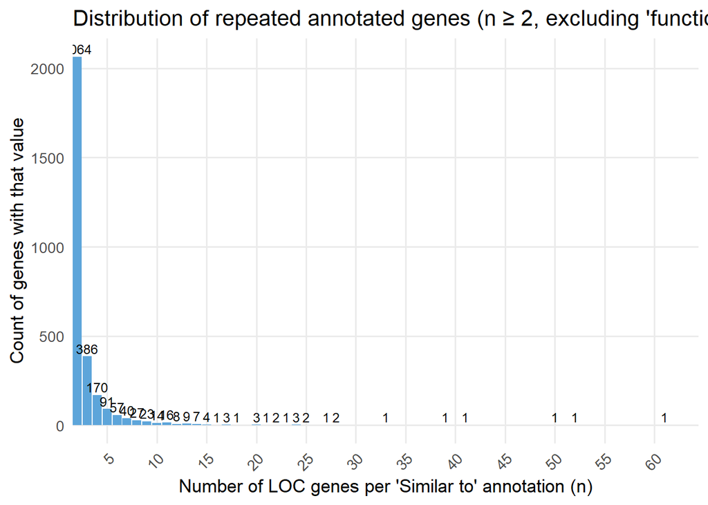

```r
library(ggplot2)
library(dplyr)

hist_data <- df5 %>%
  count(n, name = "gene_count")

ggplot(hist_data, aes(x = n, y = gene_count)) +
  geom_col(fill = "#5DA5DA") +
  geom_text(aes(label = gene_count), vjust = -0.3, size = 3.3) +
  scale_x_continuous(
    breaks = seq(0, max(hist_data$n), by = 5),      # tick every 5 units
    expand = expansion(mult = c(0, 0.05))
  ) +
  theme_minimal(base_size = 13) +
  theme(
    panel.grid.minor = element_blank(),
    axis.text.x = element_text(angle = 45, hjust = 1)
  ) +
  labs(
    x = "Number of LOC genes per 'Similar to' annotation (n)",
    y = "Count of genes with that value",
    title = "Distribution of repeated annotated genes (n ≥ 2, excluding 'function unknown')"
  )
```

**House keeper genes - In a gene body sense

```r
#Body list with cgi arquitecture
df_filtered_cgi_body <- dplyr::filter(as.data.frame(df_genes), OEindex >= 0.65, CGpercentage >= .55)
df_filtered_cgi_body
```

| geneID | Note | OEindex | CGpercentage | cluster |
| --- | --- | --- | --- | --- |
| LOC_00005748 | function unknown | 0.7776466 | 0.5641026 | 2 |
| LOC_00005974 | function unknown | 0.8834483 | 0.5901639 | 2 |
| LOC_00006468 | function unknown | 0.8498039 | 0.5532995 | 2 |
| LOC_00007237 | Similar to GHSR: Growth hormone secretagogue receptor type 1 (Oryctolagus cuniculus) | 0.8944880 | 0.5714286 | 2 |
| LOC_00007265 | Similar to Lrfn5: Leucine-rich repeat and fibronectin type-III domain-containing protein 5 (Rattus norvegicus) | 0.7829271 | 0.5590143 | 2 |
| LOC_00017541 | function unknown | 0.7757717 | 0.5585586 | 2 |
| LOC_00017625 | function unknown | 0.7431694 | 0.5580065 | 2 |
| LOC_00022859 | function unknown | 0.9175935 | 0.5537190 | 2 |
| LOC_00025528 | function unknown | 0.6947368 | 0.5530303 | 2 |
| LOC_00025762 | function unknown | 0.9653888 | 0.5693215 | 2 |

[output cut: 39 more lines]

```r
C_all_sum <- sum(C_all)
G_all_sum <- sum(G_all)
Width_all_sum <- sum(width(proteinGenes_seqs))
CG_all_sum <- sum(CG_all)
```

```r
C_all_sum <- as.numeric(C_all_sum)
G_all_sum  <- as.numeric(G_all_sum)
Width_all_sum <- as.numeric(Width_all_sum)
CG_all_sum <- as.numeric(CG_all_sum)
```

```r
#CG% sum - Body
cgContent_all_sum <- (C_all_sum+G_all_sum)/Width_all_sum
cgContent_all_sum
```

## [1] 0.4189341

```r
#OE Index sum - Body
OE_all_sum <- (CG_all_sum*Width_all_sum)/(C_all_sum*G_all_sum)
OE_all_sum
```

## [1] 0.535684

```r
#Body sums totals
C_all_sum
```

## [1] 186150604

```r
G_all_sum
```

## [1] 182375739

```r
Width_all_sum
```

## [1] 879676104

```r
CG_all_sum
```

## [1] 20673660

```r
cgContent_all_sum
```

## [1] 0.4189341

```r
OE_all_sum
```

## [1] 0.535684

```r
#Porcentaje/Ratio de GCs en el cuerpo segun el span del cuerpo
CG_all_sum/Width_all_sum
```

## [1] 0.02350145

```r
#Porcentaje/Ratio de GC del cuerpo en comparacion al genoma
genomeCG_totalcount = 45535149
CG_all_sum/45535149
```

## [1] 0.4540154

*PROMOTORES*

```r
promotores_500bp <- promoters(proteinGenes, upstream = 1000, downstream = 100)


seqlevelsStyle(promotores_500bp) <- seqlevelsStyle(genome)
promotores_500bp <- keepSeqlevels(
  promotores_500bp,
  intersect(seqlevels(promotores_500bp), seqlevels(genome)),
  pruning.mode = "coarse"
)
seqinfo(promotores_500bp) <- seqinfo(genome)[seqlevels(promotores_500bp)]
promotores_500bp <- trim(promotores_500bp)

promotores_500bp <- promotores_500bp[width(promotores_500bp) > 0]

starts <- start(promotores_500bp)
ends   <- end(promotores_500bp)
lens   <- seqlengths(promotores_500bp)[as.character(seqnames(promotores_500bp))]
start(promotores_500bp) <- pmax(1L, starts)
end(promotores_500bp)   <- pmin(ends, lens)


seqs_promotores_500bp <- getSeq(genome, promotores_500bp)

#seqs_promotores_500bp
```

**Counting**

```r
letterFrequency_all_promoters <- letterFrequency(seqs_promotores_500bp, c("A", "T", "C", "G")) %>% as.data.frame %>% tibble()
letterFrequency_all_promoters
```

| A | T | C | G |
| --- | --- | --- | --- |
| 264 | 238 | 292 | 306 |
| 325 | 270 | 266 | 239 |
| 234 | 282 | 282 | 302 |
| 264 | 298 | 248 | 290 |
| 250 | 325 | 206 | 319 |
| 396 | 231 | 259 | 214 |
| 285 | 279 | 322 | 214 |
| 256 | 271 | 245 | 328 |
| 345 | 276 | 243 | 236 |
| 285 | 347 | 230 | 238 |

[output cut: 9990 more lines]

```r
C_all_promoters <- letterFrequency_all_promoters[3]
G_all_promoters <- letterFrequency_all_promoters[4]
Width_all_promoters <- width(seqs_promotores_500bp)
CG_all_promoters <- dinucleotideFrequency(seqs_promotores_500bp)[,"CG"]
```

```r
C_all_promoters
```

| C |
| --- |
| 292 |
| 266 |
| 282 |
| 248 |
| 206 |
| 259 |
| 322 |
| 245 |
| 243 |
| 230 |

[output cut: 9990 more lines]

```r
G_all_promoters
```

| G |
| --- |
| 306 |
| 239 |
| 302 |
| 290 |
| 319 |
| 214 |
| 214 |
| 328 |
| 236 |
| 238 |

[output cut: 9990 more lines]

```r
Width_all_promoters
```

## [1] 1100 1100 1100 1100 1100 1100 1100 1100 1100 1100 1100 1100 1100 1100 1100 1100

## [17] 1100 1100 1100 1100 1100 1100 1100 1100 1100 1100 1100 1100 1100 1100 1100 1100

## [33] 1100 1100 1100 1100 1100 1100 1100 1100 1100 1100 1100 1100 1100 1100 1100 1100

## [49] 1100 1100 1100 1100 1100 1100 1100 1100 1100 1100 1100 1100 1100 1100 1100 1100

## [65] 1100 1100 1100 1100 1100 1100 1100 1100 1100 1100 1100 1100 1100 1100 1100 1100

## [81] 1100 1100 1100 1100 1100 1100 1100 1100 1100 1100 1100 1100 1100 1100 1100 1100

## [97] 1100 1100 1100 1100 1100 1100 1100 1100 1100 1100 1100 1100 1100 1100 1100 1100

## [113] 1100 1100 1100 1100 1100 1100 1100 1100 1100 1100 1100 1100 1100 1100 1100 1100

## [129] 1100 1100 1100 1100 1100 1100 1100 1100 1100 1100 1100 1100 1100 1100 1100 1100

## [145] 1100 1100 1100 1100 1100 1100 1100 1100 1100 1100 1100 1100 1100 1100 1100 1100

## [161] 1100 1100 1100 1100 1100 1100 1100 1100 1100 1100 1100 1100 1100 1100 1100 1100

## [177] 1100 1100 1100 1100 1100 1100 1100 1100 1100 1100 1100 1100 1100 1100 1100 1100

## [193] 1100 1100 1100 1100 1100 1100 1100 1100 1100 1100 1100 1100 1100 1100 1100 1100

## [209] 1100 1100 1100 1100 1100 1100 1100 1100 1100 1100 1100 1100 1100 1100 1100 1100

## [225] 1100 1100 1100 1100 1100 1100 1100 1100 1100 1100 1100 1100 1100 1100 1100 1100

## [241] 1100 1100 1100 1100 1100 1100 1100 1100 1100 1100 1100 1100 1100 1100 1100 1100

## [257] 1100 1100 1100 1100 1100 1100 1100 1100 1100 1100 1100 1100 1100 1100 1100 1100

## [273] 1100 1100 1100 1100 1100 1100 1100 1100 1100 1100 1100 1100 1100 1100 1100 1100

## [289] 1100 1100 1100 1100 1100 1100 1100 1100 1100 1100 1100 1100 1100 1100 1100 1100

## [305] 1100 1100 1100 1100 1100 1100 1100 1100 1100 1100 1100 1100 1100 1100 1100 1100

## [321] 1100 1100 1100 1100 1100 1100 1100 1100 1100 1100 1100 1100 1100 1100 1100 1100

## [337] 1100 1100 1100 1100 1100 1100 1100 1100 1100 1100 1100 1100 1100 1100 1100 1100

## [353] 1100 1100 1100 1100 1100 1100 1100 1100 1100 1100 1100 1100 1100 1100 1100 1100

## [369] 1100 1100 1100 1100 1100 1100 1100 1100 1100 1100 1100 1100 1100 1100 1100 1100

## [385] 1100 1100 1100 1100 1100 1100 1100 1100 1100 1100 1100 1100 1100 1100 1100 1100

… [1426 líneas truncadas]

```r
CG_all_promoters
```

## [1] 64 28 37 52 56 29 41 64 56 43 31 34 24 24 52 37 16 43 34 35

## [21] 17 21 71 28 29 50 10 20 57 21 60 34 31 70 55 56 16 62 68 60

## [41] 28 36 11 11 41 55 47 30 39 22 31 27 45 48 50 24 24 37 32 16

## [61] 34 35 40 34 41 40 40 37 47 61 34 31 50 31 25 37 29 24 25 45

## [81] 23 45 64 37 30 40 21 32 9 42 31 54 30 16 8 40 24 38 42 42

## [101] 32 20 16 37 36 40 25 12 44 23 16 36 38 39 48 47 31 42 35 46

## [121] 40 51 61 69 39 32 51 43 27 25 27 29 35 33 46 21 39 16 18 49

## [141] 21 39 27 36 22 37 31 7 9 16 20 34 30 20 37 6 26 39 48 50

## [161] 23 39 45 6 39 21 22 28 20 22 18 40 37 5 33 33 33 26 30 28

## [181] 34 56 16 54 38 38 42 39 16 38 33 37 14 42 40 17 50 28 32 35

## [201] 38 30 26 40 26 35 40 38 43 39 39 31 33 24 43 27 29 41 14 34

## [221] 43 43 44 27 29 30 30 47 21 45 13 24 33 22 23 47 29 40 9 31

## [241] 33 24 28 34 38 34 37 31 46 33 34 21 20 21 33 34 29 14 23 28

## [261] 10 27 43 32 68 46 33 31 26 39 38 9 35 40 36 33 42 9 30 13

## [281] 57 24 35 41 36 26 33 14 46 22 29 28 33 25 35 8 48 12 40 21

## [301] 43 51 19 47 17 50 35 28 23 27 34 4 40 23 38 33 35 33 20 31

## [321] 33 21 10 24 18 47 28 33 15 55 37 27 25 29 39 45 47 28 31 52

## [341] 42 25 31 28 30 35 32 17 34 49 54 40 26 33 18 27 35 41 30 28

## [361] 26 11 21 33 65 42 30 19 34 37 21 21 31 27 39 27 38 28 29 25

## [381] 27 29 33 28 14 27 36 69 40 30 43 7 35 33 46 29 42 51 45 15

## [401] 23 39 27 29 25 42 9 31 32 31 38 27 35 41 32 50 40 32 27 22

## [421] 35 29 42 41 33 25 42 43 36 31 28 29 33 23 15 22 18 35 33 1

## [441] 58 35 30 36 29 41 40 34 37 25 21 13 28 33 59 46 38 25 8 14

## [461] 32 23 23 19 33 38 33 11 29 28 24 34 25 53 31 28 13 31 30 27

## [481] 26 37 47 21 22 44 58 11 21 23 46 27 38 11 43 29 31 20 24 8

… [1136 líneas truncadas]

```r
OE_all_promoters = (CG_all_promoters*Width_all_promoters)/(C_all_promoters*G_all_promoters)
colnames(OE_all_promoters) <- c("OEindex")
OE_all_promoters
```

| OEindex |
| --- |
| 0.78789507 |
| 0.48447479 |
| 0.47790146 |
| 0.79532814 |
| 0.93739538 |
| 0.57554216 |
| 0.65449585 |
| 0.87605774 |
| 1.07414382 |
| 0.86408476 |

[output cut: 9990 more lines]

```r
cgContent_all_promoters = (C_all_promoters+G_all_promoters)/Width_all_promoters
colnames(cgContent_all_promoters) <- c("CGpercentage")
cgContent_all_promoters
```

| CGpercentage |
| --- |
| 0.5436364 |
| 0.4590909 |
| 0.5309091 |
| 0.4890909 |
| 0.4772727 |
| 0.4300000 |
| 0.4872727 |
| 0.5209091 |
| 0.4354545 |
| 0.4254545 |

[output cut: 9990 more lines]

```r
df_promoters <- cbind(OE_all_promoters,cgContent_all_promoters)
df_promoters
```

| OEindex | CGpercentage |
| --- | --- |
| 0.78789507 | 0.5436364 |
| 0.48447479 | 0.4590909 |
| 0.47790146 | 0.5309091 |
| 0.79532814 | 0.4890909 |
| 0.93739538 | 0.4772727 |
| 0.57554216 | 0.4300000 |
| 0.65449585 | 0.4872727 |
| 0.87605774 | 0.5209091 |
| 1.07414382 | 0.4354545 |
| 0.86408476 | 0.4254545 |

[output cut: 9990 more lines]

**Graphs**

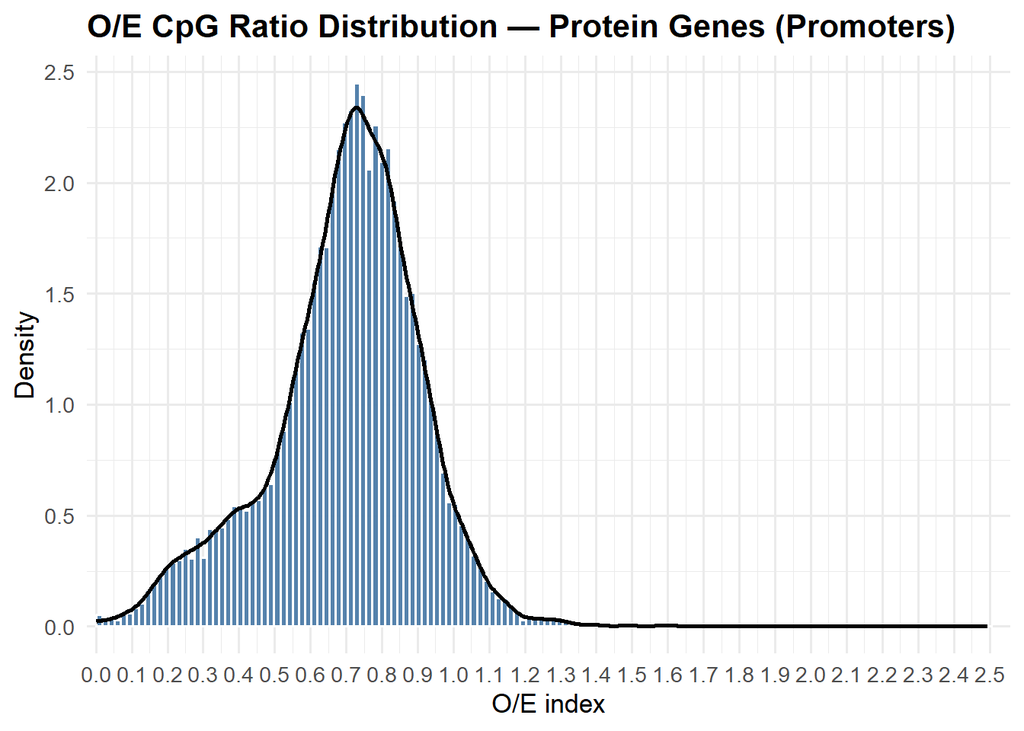

```r
x <- OE_all_promoters$OEindex
x <- x[is.finite(x)]
bw <- 2 * IQR(x) / length(x)^(1/3)
if (!is.finite(bw) || bw <= 0) bw <- diff(range(x)) / 80
xmin <- floor(min(x) * 10) / 10
xmax <- ceiling(max(x) * 10) / 10

ggplot(OE_all_promoters, aes(x = OEindex)) +
  geom_histogram(aes(y = after_stat(density)),
                 binwidth = bw, boundary = 0, closed = "left",
                 fill = "#4C7BA8", color = "white", alpha = 0.95) +
  geom_density(linewidth = 0.9, color = "black", alpha = 0.6) +
  scale_x_continuous(
    breaks = seq(xmin, xmax, by = 0.1),
    minor_breaks = seq(xmin, xmax, by = 0.05),
    labels = number_format(accuracy = 0.1),
    expand = expansion(mult = c(0.01, 0.02))
  ) +
  labs(
    title = "O/E CpG Ratio Distribution — Protein Genes (Promoters)",
    x = "O/E index",
    y = "Density"
  ) +
  theme_minimal(base_size = 13) +
  theme(
    panel.grid.minor = element_line(),
    plot.title = element_text(face = "bold")
  )
```

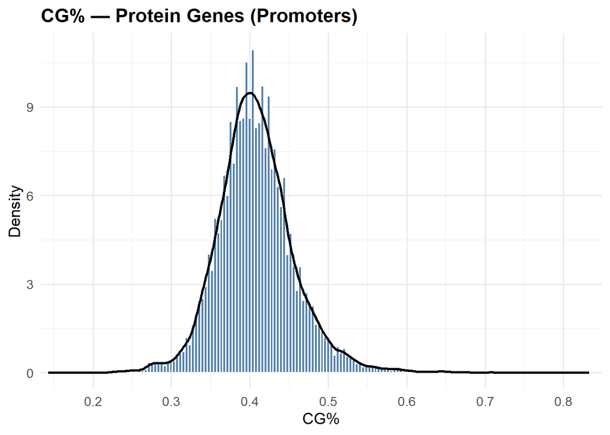

```r
x <- cgContent_all_promoters$CGpercentage
x <- x[is.finite(x)]
bw <- 2 * IQR(x) / length(x)^(1/3)
if (!is.finite(bw) || bw <= 0) bw <- diff(range(x)) / 80
xmin <- floor(min(x) * 10) / 10
xmax <- ceiling(max(x) * 10) / 10

ggplot(cgContent_all_promoters, aes(x = CGpercentage)) +
  geom_histogram(aes(y = after_stat(density)),
                 binwidth = bw, boundary = 0, closed = "left",
                 fill = "#4C7BA8", color = "white", alpha = 0.95) +
  geom_density(linewidth = 0.9, color = "black", alpha = 0.6) +
  scale_x_continuous(
    breaks = seq(xmin, xmax, by = 0.1),
    minor_breaks = seq(xmin, xmax, by = 0.05),
    labels = number_format(accuracy = 0.1),
    expand = expansion(mult = c(0.01, 0.02))
  ) +
  labs(
    title = "CG% — Protein Genes (Promoters)",
    x = "CG%",
    y = "Density"
  ) +
  theme_minimal(base_size = 13) +
  theme(
    panel.grid.minor = element_line(),
    plot.title = element_text(face = "bold")
  )
```

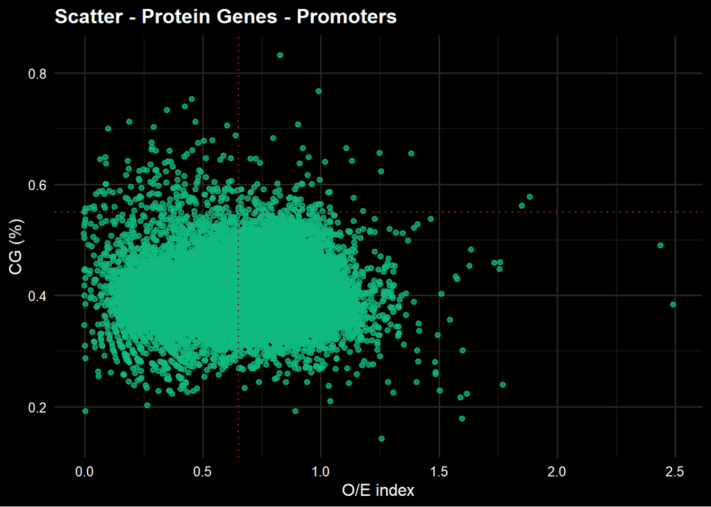

```r
plot_nice_dark <- function(d, x="OEindex", y="CGpercentage",
                           xthr=.65, ythr=.55, title="Scatter - Protein Genes - Promoters",
                           point_col="#10b981", thr_col="#7f1d1d"){   # green, violet
  dd <- data.frame(x=as.numeric(d[[x]]), y=as.numeric(d[[y]]))
  dd <- dd[is.finite(dd$x) & is.finite(dd$y), ]
  ggplot(dd, aes(x, y)) +
    geom_point(color=point_col, alpha=.75, size=1.6,
               position=position_jitter(width=.004, height=0)) +
    geom_vline(xintercept=xthr, color=thr_col, linewidth=.6, linetype="dotted") +
    geom_hline(yintercept=ythr, color=thr_col, linewidth=.6, linetype="dotted") +
    labs(title=title, x="O/E index", y="CG (%)") +
    theme_minimal(base_size=12) +
    theme(
      plot.background  = element_rect(fill="black", color=NA),
      panel.background = element_rect(fill="black", color=NA),
      panel.grid       = element_line(color="#242424"),
      axis.text        = element_text(color="white"),
      axis.title       = element_text(color="white"),
      plot.title       = element_text(color="white", face="bold")
    )
}

# use:
plot_nice_dark(df_promoters)
```

**PCA**

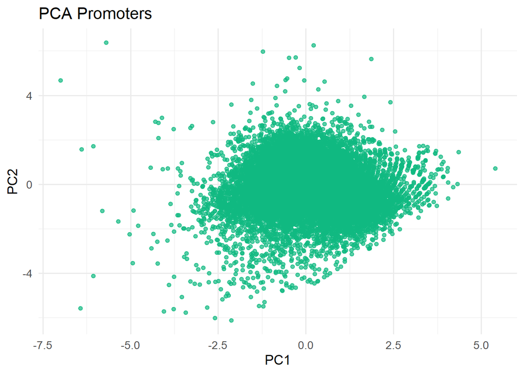

```r
# 1) Clean: keep numeric cols, drop NA/Inf rows, drop zero-variance cols
X <- df_promoters[, sapply(df_promoters, is.numeric), drop = FALSE]
X <- X[Reduce(`&`, lapply(X, is.finite)), , drop = FALSE]
X <- X[, sapply(X, function(z) sd(z) > 0), drop = FALSE]

# 2) PCA
pca <- prcomp(X, center = TRUE, scale. = TRUE)
pc  <- as.data.frame(pca$x[, 1:2, drop = FALSE])

ggplot(pc, aes(PC1, PC2)) +
  geom_point(alpha = .7, size = 1.6, color = "#10b981") +
  theme_minimal(base_size = 13) +
  labs(title = "PCA Promoters", x = "PC1", y = "PC2")
```

```r
summary(pca)
```

## Importance of components:

## PC1 PC2

## Standard deviation 1.0113 0.9886

## Proportion of Variance 0.5113 0.4886

## Cumulative Proportion 0.5113 1.0000

```r
cor(df$OEindex, df$CGpercentage)
```

## [1] NA

**K-Means**

[figure not shown]

```r
# clean once; keep the mask so we can put labels back correctly
X <- df_promoters[, c("OEindex","CGpercentage")]
m <- is.finite(X$OEindex) & is.finite(X$CGpercentage)
Xc <- scale(X[m, , drop=FALSE])

set.seed(42)
k  <- 2
km <- kmeans(Xc, centers=k, nstart=50)

df$cluster <- NA_integer_
df$cluster[m] <- km$cluster
df$cluster <- factor(df$cluster)

ggplot(df[!is.na(df$cluster),], aes(OEindex, CGpercentage, color=cluster)) +
  geom_point(alpha=.75, size=1.7) +
  theme_minimal(base_size=13) +
  labs(title=sprintf("k-means (k=%d) Promoters", k),
       x="O/E index", y="CG (%)")
```

```r
df_promoters
```

| OEindex | CGpercentage |
| --- | --- |
| 0.78789507 | 0.5436364 |
| 0.48447479 | 0.4590909 |
| 0.47790146 | 0.5309091 |
| 0.79532814 | 0.4890909 |
| 0.93739538 | 0.4772727 |
| 0.57554216 | 0.4300000 |
| 0.65449585 | 0.4872727 |
| 0.87605774 | 0.5209091 |
| 1.07414382 | 0.4354545 |
| 0.86408476 | 0.4254545 |

[output cut: 9990 more lines]

```r
df_promoters <- data.frame(
  geneID = geneinfo$geneID,
  Note = S4Vectors::unstrsplit(geneinfo$Note, sep = "; "), df_promoters
)

df_promoters
```

| geneID | Note | OEindex | CGpercentage |
| --- | --- | --- | --- |
| LOC_00005583 | Similar to ems: Homeotic protein empty spiracles (Drosophila melanogaster) | 0.78789507 | 0.5436364 |
| LOC_00005584 | Similar to Cyp20a1: Cytochrome P450 20A1 (Mus musculus) | 0.48447479 | 0.4590909 |
| LOC_00005585 | Similar to CNBD2: Cyclic nucleotide-binding domain-containing protein 2 (Homo sapiens) | 0.47790146 | 0.5309091 |
| LOC_00005586 | function unknown | 0.79532814 | 0.4890909 |
| LOC_00005587 | Similar to MTX1: Metaxin-1 (Sus scrofa) | 0.93739538 | 0.4772727 |
| LOC_00005588 | Similar to NEIL1: Endonuclease 8-like 1 (Homo sapiens) | 0.57554216 | 0.4300000 |
| LOC_00005589 | function unknown | 0.65449585 | 0.4872727 |
| LOC_00005590 | Similar to DNTT: DNA nucleotidylexotransferase (Ambystoma mexicanum) | 0.87605774 | 0.5209091 |
| LOC_00005591 | Similar to DDX56: Probable ATP-dependent RNA helicase DDX56 (Homo sapiens) | 1.07414382 | 0.4354545 |
| LOC_00005592 | Similar to Haspin: Serine/threonine-protein kinase haspin (Mus musculus) | 0.86408476 | 0.4254545 |

[output cut: 9990 more lines]

```r
#Promoters list with cgi arquitecture


df_filtered_cgi_promoters <- dplyr::filter(as.data.frame(df_promoters), OEindex >= 0.65, CGpercentage >= .55)
df_filtered_cgi_promoters
```

| geneID | Note | OEindex | CGpercentage |
| --- | --- | --- | --- |
| LOC_00005616 | Similar to cAMP-dependent protein kinase type II regulatory subunit (Strongylocentrotus purpuratus) | 0.7946336 | 0.5681818 |
| LOC_00005618 | function unknown | 0.6650185 | 0.5909091 |
| LOC_00006321 | Similar to LAC: Lachesin (Schistocerca americana) | 0.6934594 | 0.5745455 |
| LOC_00006432 | Similar to DTX3L: E3 ubiquitin-protein ligase DTX3L (Homo sapiens) | 0.7615260 | 0.5554545 |
| LOC_00007239 | function unknown | 0.8182841 | 0.6018182 |
| LOC_00007249 | Similar to SORD: Sorbitol dehydrogenase (Gallus gallus) | 0.9980394 | 0.6081818 |
| LOC_00017272 | Similar to CDHR1: Cadherin-related family member 1 (Gallus gallus) | 1.0073927 | 0.5518182 |
| LOC_00017309 | Similar to LMO1: Rhombotin-1 (Bos taurus) | 1.0362299 | 0.5590909 |
| LOC_00022574 | Similar to CARNMT1: Carnosine N-methyltransferase (Homo sapiens) | 1.8532609 | 0.5618182 |
| LOC_00025736 | function unknown | 0.7837453 | 0.5645455 |

[output cut: 84 more lines]

```r
sum(grepl("^\\s*function\\s+unknown\\b", df_filtered_cgi_promoters$Note, ignore.case = TRUE))
```

## [1] 44

**Promoters Sum Count**

```r
C_all_sum_promoters <- sum(C_all_promoters)
G_all_sum_promoters <- sum(G_all_promoters)
Width_all_sum_promoters <- sum(width(seqs_promotores_500bp))
CG_all_sum_promoters <- sum(CG_all_promoters)
```

```r
C_all_sum_promoters <- as.numeric(C_all_sum_promoters)
G_all_sum_promoters  <- as.numeric(G_all_sum_promoters)
Width_all_sum_promoters <- as.numeric(Width_all_sum_promoters)
CG_all_sum_promoters <- as.numeric(CG_all_sum_promoters)
```

```r
C_all_sum_promoters
```

## [1] 5241453

```r
G_all_sum_promoters
```

## [1] 5174866

```r
Width_all_sum_promoters
```

## [1] 25537600

```r
CG_all_sum_promoters
```

## [1] 732707

```r
#CG% sum - Body
cgContent_all_sum_promoters <- (C_all_sum_promoters+G_all_sum_promoters)/Width_all_sum_promoters
cgContent_all_sum_promoters
```

## [1] 0.4078817

```r
#OE Index sum - Body
OE_all_sum_promoters <- (CG_all_sum_promoters*Width_all_sum_promoters)/(C_all_sum_promoters*G_all_sum_promoters)
OE_all_sum_promoters
```

## [1] 0.6898579

```r
#Body sums totals
C_all_sum_promoters
```

## [1] 5241453

```r
G_all_sum_promoters
```

## [1] 5174866

```r
Width_all_sum_promoters
```

## [1] 25537600

```r
CG_all_sum_promoters
```

## [1] 732707

```r
cgContent_all_sum_promoters
```

## [1] 0.4078817

```r
OE_all_sum_promoters
```

## [1] 0.6898579

```r
#Porcentaje/Ratio de GCs en el cuerpo segun el span del promoters
CG_all_sum_promoters/Width_all_sum_promoters
```

## [1] 0.0286913

```r
#Porcentaje/Ratio de GC del cuerpo en comparacion al genoma
genomeCG_totalcount = 45535149
CG_all_sum_promoters/45535149
```

## [1] 0.01609102